# Capsule 3 - Diagnostiquer dans le temps

MQT-2101 - Analyse et modélisation des données

## Pourquoi ça compte

Les erreurs successives sont-elles liées?

Des erreurs qui se suivent peuvent révéler une structure que les prédicteurs n’expliquent pas.

## Objectifs de la capsule

- Distinguer résidu et erreur de prévision.
- Lire la fonction d’autocorrélation des résidus.
- Expliquer les limites du diagnostic.

## Deux écarts, deux moments

Sur les mois d’entraînement

Résidu = vente observée moins vente ajustée. Le mois étudié a servi à estimer les coefficients.

Sur un mois tenu à part

Erreur de prévision = vente observée moins prévision produite avec le modèle déjà ajusté.

## Calculer un résidu avant de lire le graphique

Résidu = vente observée − vente ajustée  
Juillet 2020 : 316 643 $ − 338 760 $ ≈ −22 117 $

Placez le point sous la ligne zéro. Le modèle surestime la vente de juillet. De quel côté placeriez-vous un mois où le modèle sous-estime les ventes ?

## Suivre une séquence de mois

| 2020 | Mai | Juin | Juillet | Août |
| --- | --- | --- | --- | --- |
| Résidu arrondi | −1 992 $ | −5 073 $ | −22 117 $ | −11 969 $ |

Durant ces quatre mois, le modèle surestime à chaque fois. Pour savoir si cette persistance se répète, il faut examiner les 60 résidus.

## Fabriquer les paires d’un retard

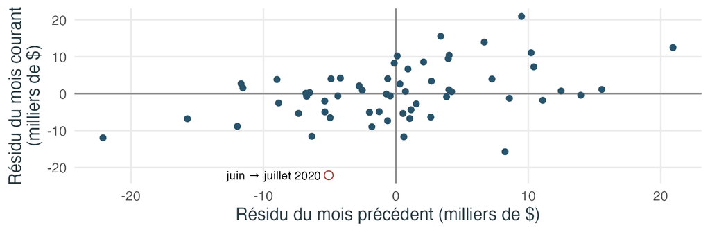

Au retard 1, juin et juillet donnent le point (−5,1 , −22,1) en milliers de dollars. Au retard 12, associez janvier 2020 à janvier 2021. Combien de paires restent-elles ?

## Demander les autocorrélations à R

```r
r <- residuals(modele_lm)
a <- acf(r, lag.max = 12, plot = FALSE)
data.frame(retard = as.numeric(a$lag),
           acf = round(as.numeric(a$acf), 2))
```

La première ligne correspond au retard 0. Sa valeur de 1 vient de la comparaison de la série avec elle-même.

## Autocorrélation des résidus de 2020 à 2024

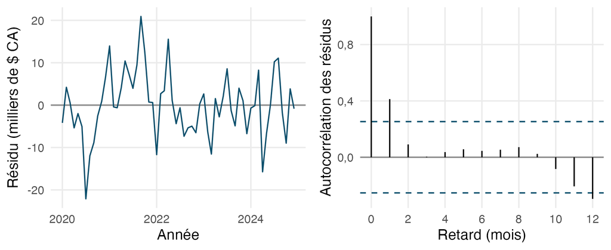

Les pointillés sont des repères approximatifs, pas une preuve d’indépendance.

## Lire deux barres de signes opposés

Au retard 1 : +0,41

Des écarts de même sens tendent à se suivre. Le tracé temporel permet de localiser les mois en cause.

Au retard 12 : −0,30

Les écarts à un an de distance tendent à être de sens opposés. Une explication saisonnière demanderait d’autres éléments.

## Du diagnostic à une comparaison

Les repères individuels valent environ ±1,96 / √60, soit ±0,25. Deux barres les franchissent. Que proposez-vous d’essayer ?

Tester un modèle où l’écart d’un mois dépend de celui du mois précédent, puis comparer ses prévisions. Le graphique seul ne désigne pas le meilleur modèle.

## À retenir

Résidus

écarts après ajustement, distincts des erreurs de prévision

Retards

comparer les résidus à un ou plusieurs mois d’intervalle

Limite

une autocorrélation peu marquée ne prouve pas l’indépendance

## Production autonome 9.3

Tracez les résidus de la régression en fonction du temps et leur autocorrélation. Décrivez les motifs observés et expliquez pourquoi ils ne prouvent pas à eux seuls l’indépendance des résidus.

Cette production se réalise une seule fois dans le rapport guidé.

### Auto-vérification

- Je garde l’ordre des mois et distingue résidus et erreurs de prévision.
- Je décris les retards et les motifs visibles.
- Je sais qu’une ACF peu marquée ne prouve pas l’indépendance.

## Références et crédits

Matériel du cours MQT-2101, Université Laval. Données fictives simulées pour l’enseignement.

Hyndman et Athanasopoulos (2021), *Forecasting: Principles and Practice*, 3e édition.